# Developing Data Products - Slide Pitch

6/26/2017

## Objectives

- Build a shiny application with documentation
  - showing use of user input widgets and
  - calculations on server side based on user input values
- Host the application on a shiny server
- Publish a set of 5 slides to pitch the applciation
- The data set "iris" from R is used. See references.
  - The source code for the project can be found in github public repository
  - https://github.com/b-mc-g/developing_data_products_w4/tree/master
  - Presentation data can be found using gh.pages link in browser here
  - http://b-mc-g.github.io/developing_data_products_w4/index.html

## Application

- The application uses the "iris" data preloaded with R
- On right of the screen
  - Petal and Sepal width and length are plotted on 4 graphs
- On left of screen
  - Four sliders allow the values to be set
  - These could be used to enter actual measurement
- Bottom Left there is a Predict Species button
  - This allows the set slider values to be entered
  - into a random forest model geberated using the "iris" data
  - the predicted species is returned and show in table form to the user
  - values are shown as decimals that add up to 1

## Example Graph used in the application

- Sepal Length probalilty densities for the 3 Species
- The app allows the user to set measurement values using sliders

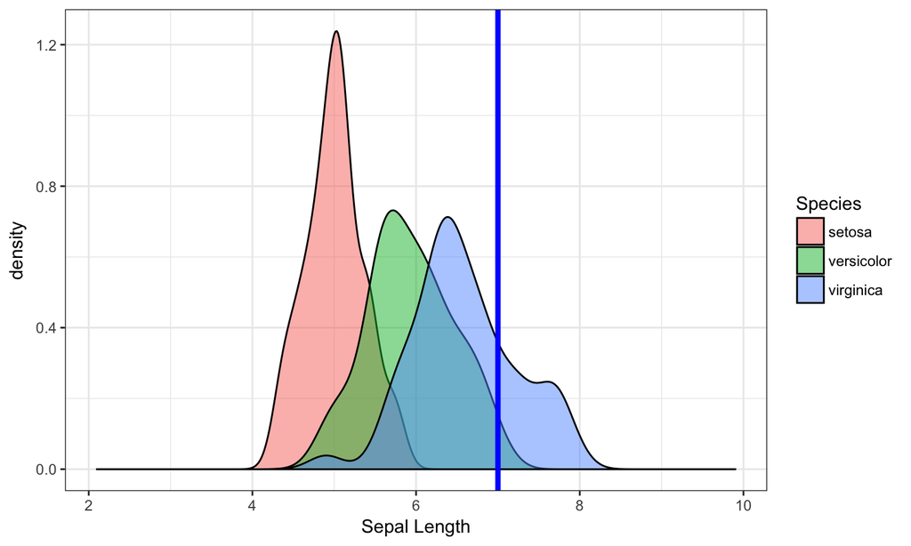

## Additional References

- https://stat.ethz.ch/R-manual/R-devel/library/datasets/html/iris.html
- https://shiny.rstudio.com/tutorial/
- https://shiny.rstudio.com/articles/
- https://shiny.rstudio.com/gallery/